# Tables in R - Data frames and Tibbles

Day 1 - Introduction to Data Analysis with R

Selina Baldauf

Freie Universität Berlin - Theoretical Ecology

October 17, 2026

## Data frames

The built-in data structure for tables in R is a **data frame**.

Vectors in R can’t represent a data table where values are connected via rows

> Data frames are one of the **biggest and most important ideas** in R, and one of the things that make R different from other programming languages.  
> (H. Wickham, [Advanced R](https://adv-r.hadley.nz/vectors-chap.html#tibble))

| city_name | population_size | city_area |
| --- | --- | --- |
| Istanbul | 15100000 | 2576 |
| Moscow | 12500000 | 2561 |
| London | 9000000 | 1572 |
| Saint Petersburg | 5400000 | 1439 |
| Berlin | 3800000 | 891 |
| Madrid | 3200000 | 604 |
| Kyiv | 3000000 | 839 |
| Rome | 2800000 | 1285 |
| Bucharest | 2200000 | 228 |
| Paris | 2100000 | 105 |

## Properties of a data frame

A data frame is a **named list of vectors** of the same length.

- every column is a vector
- columns have a header
- within one column, all values are of the same data type
- every column has the same length

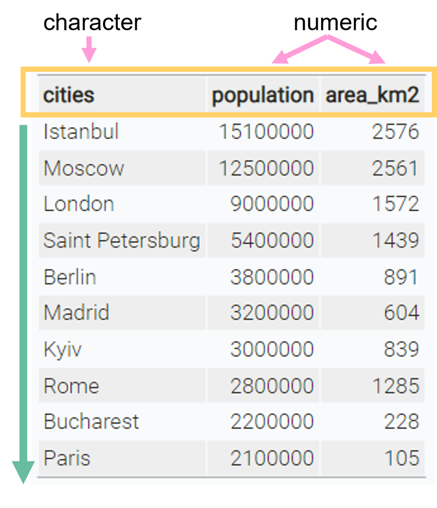

## Creating data frames

Data frames are created with the function `data.frame()`:

```r
cities <- c(
  "Istanbul", "Moscow", "London",
  "Saint Petersburg", "Berlin","Madrid",
  "Kyiv", "Rome", "Bucharest","Paris")

population <- c(
  15.1e6, 12.5e6, 9e6, 5.4e6, 3.8e6,
  3.2e6, 3e6, 2.8e6, 2.2e6, 2.1e6)

area_km2 <- c(2576, 2561, 1572, 1439,
  891, 604, 839, 1285, 228, 105)

cities_dataframe <- data.frame(
  city_name = cities,
  population_size = population,
  city_area = area_km2
  )
```

```
#>           city_name population_size city_area
#> 1          Istanbul        15100000      2576
#> 2            Moscow        12500000      2561
#> 3            London         9000000      1572
#> 4  Saint Petersburg         5400000      1439
#> 5            Berlin         3800000       891
#> 6            Madrid         3200000       604
#> 7              Kyiv         3000000       839
#> 8              Rome         2800000      1285
#> 9         Bucharest         2200000       228
#> 10            Paris         2100000       105
```

## Tibbles

Tibbles are

> a **modern reimagining of the data frame**. Tibbles are designed to be (as much as possible) **drop-in replacements** for data frames.  
> (Wickham, [Advanced R](https://adv-r.hadley.nz/vectors-chap.html#tibble))

Have a look at [this book chapter](https://adv-r.hadley.nz/vectors-chap.html#tibble) for a full list of the differences between data frames and tibbles and the advantages of using tibbles.

- Tibbles have the same basic properties as data frames
- Everything that you can do with data frames, you can do with tibbles
- Tibbles are part of the `tibble` package

## Packages

**Base R** functions and data types: built into R

```r
mean()         # calculate mean
summary()      # show summary of a table
data.frame()   # create a data frame
```

**Additional packages** extend R with new functions and data types

```r
# install once (in the console, not in the script)
install.packages("packageName")

# load every time R restarts (at the top of your script)
library(packageName)
```

## Tibbles

Create a tibble using the `tibble()` function:

```r
# install the tibble package once
# install.packages("tibble")
library(tibble)

cities_tbl <- tibble(
  city_name = cities,
  population_size = population,
  city_area = area_km2
)
```

```
#> # A tibble: 10 × 3
#>    city_name        population_size city_area
#>    <chr>                      <dbl>     <dbl>
#>  1 Istanbul                15100000      2576
#>  2 Moscow                  12500000      2561
#>  3 London                   9000000      1572
#>  4 Saint Petersburg         5400000      1439
#>  5 Berlin                   3800000       891
#>  6 Madrid                   3200000       604
#>  7 Kyiv                     3000000       839
#>  8 Rome                     2800000      1285
#>  9 Bucharest                2200000       228
#> 10 Paris                    2100000       105
```

## Exploring tibbles

How many rows?

```r
nrow(cities_tbl)
```

```
#> [1] 10
```

How many columns?

```r
ncol(cities_tbl)
```

```
#> [1] 3
```

What are the column headers?

```r
names(cities_tbl)
```

```
#> [1] "city_name"       "population_size" "city_area"
```

## Exploring tibbles

Look at the entire table in a separate window with `view()`:

```r
view(cities_tbl)
```

## Exploring tibbles

Get a quick summary of all columns:

```r
summary(cities_tbl)
```

```
#>   city_name         population_size      city_area
#>  Length:10          Min.   : 2100000   Min.   : 105.0
#>  Class :character   1st Qu.: 2850000   1st Qu.: 662.8
#>  Mode  :character   Median : 3500000   Median :1088.0
#>                     Mean   : 5910000   Mean   :1210.0
#>                     3rd Qu.: 8100000   3rd Qu.:1538.8
#>                     Max.   :15100000   Max.   :2576.0
```

- Very useful for checking if everything is ok with your research data

## Indexing tibbles

Indexing tibbles works similar to indexing vectors but with 2 dimensions instead of 1:

**tibble [ row_index, col_index or col_name ]**

- Missing row_index or col_index means *all rows* or *all columns* respectively.
- Indexing a tibble using `[]` always returns another tibble.

## Indexing tibbles

```r
# First row and first column
cities_tbl[1, 1]
```

```
#> # A tibble: 1 × 1
#>   city_name
#>   <chr>
#> 1 Istanbul
```

This is the same as

```r
cities_tbl[1, "city_name"]
```

## Indexing tibbles: rows

```r
# rows 1 & 5, all columns:
cities_tbl[c(1, 5), ]
```

```
#> # A tibble: 2 × 3
#>   city_name population_size city_area
#>   <chr>               <dbl>     <dbl>
#> 1 Istanbul         15100000      2576
#> 2 Berlin            3800000       891
```

## Indexing tibbles: columns

```r
# All rows, first 2 columns
cities_tbl[ ,1:2] # same as cities_tbl[ , c(1, 2)]
# same as
cities_tbl[ ,c("city_name", "population_size")]
```

```
#> # A tibble: 10 × 2
#>   city_name population_size
#>   <chr>               <dbl>
#> 1 Istanbul         15100000
#> 2 Moscow           12500000
#> 3 London            9000000
#> # ℹ 7 more rows
```

## Indexing tibbles: columns

Indexing columns by name is usually preferred to indexing by position

```r
cities_tbl[ ,1:2] # okay
cities_tbl[ ,c("city_name", "population_size")] # better
```

#### Why?

- Code is much easier to read
- Code is more robust against
  - changes in column order
  - mistakes in the code (e.g. typos)

```r
cities_tbl[ ,c(1,3)] # 3 instead of 2 -> wrong but no error
cities_tbl[ ,c("city_name", "popluation_size")] # typo -> wrong and error
```

**General rule**

Good code produces errors when something unintended or wrong happens

## Tibbles: Select columns with `$`

Select an entire column from a tibble using `$` (this returns a vector instead of a tibble):

```r
cities_tbl$city_name
```

```
#>  [1] "Istanbul"         "Moscow"           "London"           "Saint Petersburg"
#>  [5] "Berlin"           "Madrid"           "Kyiv"             "Rome"
#>  [9] "Bucharest"        "Paris"
```

## Adding new columns

New columns can be added as vectors using the `$` operator. The vectors need to have the same length as the tibble has rows.

```r
# add a country column
cities_tbl$country <- c(
  "Turkey", "Russia", "UK", "Russia", "Germany", "Spain",
  "Ukraine", "Italy", "Romania", "France"
)
```

```
#> # A tibble: 10 × 4
#>    city_name        population_size city_area country
#>    <chr>                      <dbl>     <dbl> <chr>
#>  1 Istanbul                15100000      2576 Turkey
#>  2 Moscow                  12500000      2561 Russia
#>  3 London                   9000000      1572 UK
#>  4 Saint Petersburg         5400000      1439 Russia
#>  5 Berlin                   3800000       891 Germany
#>  6 Madrid                   3200000       604 Spain
#>  7 Kyiv                     3000000       839 Ukraine
#>  8 Rome                     2800000      1285 Italy
#>  9 Bucharest                2200000       228 Romania
#> 10 Paris                    2100000       105 France
```

## Summary I

- Install and load a package before using it:

```r
# install the tibble package once
# install.packages("tibble")
library(tibble)
```

#### Creating tibbles and data frames

```r
# data frame
data.frame(
  a = 1:3,
  b = c("a", "b", "c"),
  c = c(TRUE, FALSE, FALSE)
)
# tibble
tibble(
  a = 1:3,
  b = c("a", "b", "c"),
  c = c(TRUE, FALSE, FALSE)
)
```

## Summary II

#### Looking at tibble structure

```r
# number of rows
nrow(tbl)
# number of columns
ncol(tbl)
# column headers
names(tbl)
# look at the data in a new window
view(tbl)
# summary of values from each column
summary(tbl)
```

## Summary III

#### Indexing tibbles and selecting columns

Return result as tibble:

```r
# rows and columns by position
tbl[1:3, c(1, 3)]
tbl[1:3, ] # all columns
tbl[, 3] # column 3, all rows
tbl[3] # same as above

# columns by name
tbl[, c("colA", "colB")]
tbl[c("colA", "colB")]
```

Return result as vector:

```r
tbl$colA # select colA
```

# Now you

Task (15 min)

Tibbles

**Find the task description [here](https://selinazitrone.github.io/intro-r-data-analysis/sessions/04_data-tibbles.html)**